# Reproducible Research Peer Assessment 1

KiloNovember

April 19, 2015

# Loading and preprocessing the data

Here’s my code for loading the activity.csv file into a data frame. The data must first be downloaded and unzipped to a file system location you choose which you will subesequently use for the “filepath” argument to this function. The data can be found at:

https://d396qusza40orc.cloudfront.net/repdata%2Fdata%2Factivity.zip

```
loadData <- function(filepath){
  activity<-read.csv(filepath)
  activity
}
```

```r
  df<- loadData("activity.csv")
```

# What is mean total number of steps taken per day?

```
mean.steps <-function(df){
  # Compute mean steps per day, eliminating rows with NA value for steps.
  # Collect total number of steps per day
 spd <- aggregate(df$steps, list(df$date), sum, na.rm=TRUE)

  #Compute mean
  mean(spd$x)
}
```

##### Mean steps per day

```r
    mean.steps(df)
```

```
## [1] 9354.23
```

```
median.steps <-function(df){
  # Compute median steps per day, eliminating rows with NA value for steps

  # Collect total number of steps per day
  spd <- aggregate(df$steps, list(df$date), sum, na.rm=TRUE)

  #Compute median
  median(spd$x)
}
```

##### Median steps per day

```r
    median.steps(df)
```

```
## [1] 10395
```

### A histogram of steps taken per day with a bin-width of 1000 steps

```
histo.steps <- function(df){
  agg <- aggregate(df$steps, list(df$date), sum, na.rm=TRUE)
  ggplot(agg, aes(x=x)) + geom_histogram(data=agg$steps, binwidth = 1000, color="black", fill="white") +  scale_y_continuous(breaks=seq(0, 20, 1)) + ylab("Count of Days") + xlab("Steps per Day")
}
```

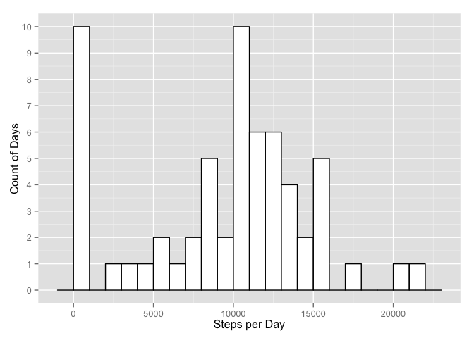

```r
  require("ggplot2", lib.loc="/Library/Frameworks/R.framework/Versions/3.1/Resources/library")
  histo.steps(df)
```

# What is the average daily activity pattern?

```
ts.plot <- function(df){
  spi <- aggregate(df$steps, list(df$interval), mean, na.rm=TRUE)
  ggplot(spi, aes(x=Group.1, y=x)) + geom_line() + ylab("Steps") + xlab("5-minute Interval")
}
```

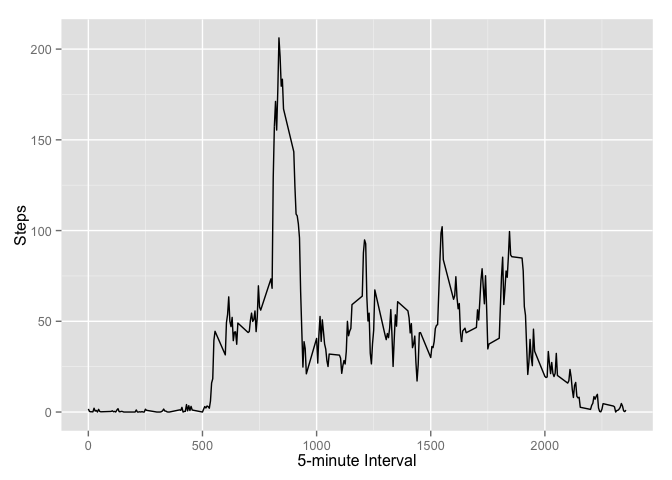

```r
  ts.plot(df)
```

##### Five-minute interval with the highest average number of steps

```
steps.grouped.by.interval <- function(df){
  # Compute the mean number of steps per five-minute interval over the period of the data set
  aggregate(df$steps, list(df$interval), mean, na.rm=TRUE)
}
```

```r
    sgbi <- steps.grouped.by.interval(df)
    colnames(sgbi) <- c("Interval", "Mean_Steps")
    sgbi[sgbi$Mean_Steps == max(sgbi$Mean_Steps),]
```

```
##     Interval Mean_Steps
## 104      835   206.1698
```

# Imputing missing values

## Calculate and report the total number of missing values in the dataset

```
count.NAs <- function(df){
  length(which(is.na(df)))
}
```

```r
  count.NAs(df)
```

```
## [1] 2304
```

## Synthetic data set with NAs replaced by the mean value of identical periods in the days where a value has been recorded

The data for the missing five-minute periods was synthesized by computing the mean values for the corresponding periods on those days for which actual step counts are recorded. These mean values were then imputed to the periods for which no data was recorded.

```
synthesize.missing.data <- function(df){
  incomplete.cases <- subset.NAs(df)
  mean.steps.pi <- mean.steps.per.interval(df)

  # Loop through the incomplete cases, and select from the mean.steps
  # data frame the calculated mean value for the matching 5-minute period
  # and assign it to the corresponding NA value

  for(i in 1:nrow(incomplete.cases)){
      interval.number <- incomplete.cases[i,3]
      incomplete.cases[i,1] <- mean.steps.pi[mean.steps.pi$Group.1 == interval.number,2]
  }

    # The formerly incomplete rows in incomplete.cases now have
    # been made artifically complete by inserting into the "steps" column,
    # the value of the average number of steps taken during the
    # corresponding interval in the days where data was recorded

    incomplete.cases
}
```

```r
  synth.obs <- synthesize.missing.data(df)
```

### Subset the complete cases for later combination with synthetic cases

```
subset.complete.cases <- function(df){
  complete <- subset(df, !is.na(steps))
  complete
}
```

```r
  actual.obs <- subset.complete.cases(df)
```

### Create a new dataset that is equal to the original dataset but with the missing data filled in.

```
merge.datasets <- function(synth.obs, actual.obs){
  # synth.obs are those rows with the synthesized
  # value for the "steps" column.
  # actual.obs are those rows with recorded values

  # for the "steps" column

  rbind(synth.obs,actual.obs)
}
```

```r
  merged.data <- merge.datasets(synth.obs, actual.obs)
```

### A histogram of steps taken per day with a bin-width of 1000 steps, merged data set

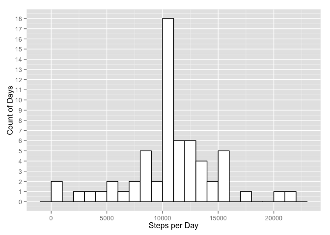

```r
    histo.steps(merged.data)
```

### Mean and Median Values for the Merged Data Set

##### Mean

```r
    mean.steps(merged.data)
```

```
## [1] 10766.19
```

##### Median

```r
    median.steps(merged.data)
```

```
## [1] 10766.19
```

##### Effects:

# Are there differences in activity patterns between weekdays and weekends?

##### Add a Weekday/Weekend Factor Variable

```
add.weekday.factor<- function(df){
  df$weekday <- as.factor(weekdays(as.Date(df$date)) %in% c("Saturday", "Sunday"))
  levels(df$weekday)[levels(df$weekday) == FALSE] <- "Weekend"
  levels(df$weekday)[levels(df$weekday) == TRUE] <- "Weekday"
  df
}
```

```r
  weekday.factored.dataframe <- add.weekday.factor(merged.data)
```

##### Comparison of Activity Patterns, Weekends vs. Weekdays

```
weekday.vs.weekend.plot <- function(df){
  spi <- aggregate(df$steps, list(df$interval, df$weekday), mean, na.rm=TRUE)
  ggplot(spi, aes(x=Group.1, y=x)) + geom_line() + ylab("Steps") + xlab("5-minute Interval") + facet_wrap(~ Group.2)
}
```

[figure not shown]

```r
  weekday.vs.weekend.plot(weekday.factored.dataframe)
```